# Sampling, Re-Sampling, and Two Amazing Results

Josh Clinton

8/8/2021

# Motivating questions:

- What is random sampling and why is random sampling so powerful as a method of collecting data?
- What is the logic of using only 1000 people to try to measure the public opinion of 350 million people?
- If my data is a random sample, how many observations do I need to calculate a mean that is an accurate estimate?
- How much uncertainty should I have about an estimate depending on my sample size?
- How much better is a sample of size 1000 than a sample of size 100? In what way or ways is it better?

# New Skills

- `sample`
- `sample_n`
- for loops
- `seq_along`
- `cut`

How the data we analyze is collected is really important and has profound implications for what we can use the data to learn about. While we often want to jump right in to the analysis, thinking about where the data comes from is an essential first step.

To help, let’s define two terms: *Population* and *Sample*.

A *Sample* is simply the data that you are able to analyze. It could be a few observations or hundreds of millions. Somewhat confusingly, it does not have to be gathered by intentionally sampling anything. If you were to write down the temperature each day for 100 days, that would be a `sample` of temperature data. If I were to write some public opinion questions and then ask them to the first ten people I met to record their responses that would also be a smaple of public opinion data. Not a very good sample, but a sample nonetheless. Whatever data you are able to analyze is a *sample* – think about `sample` in this context as meaning simply ``selection."

The *Population* is the set of observations to which the sample belongs.what you want to learn about. This is where things get a bit tricky and confusing. In statistics, we can never observe *population* – it is a hypothetical construct about the observations of interest because it includes cases that have yet to happen. Seem weird? Let’s try to explain this. Suppose that you collected data on the national popular vote for every presidential election in the United States to the current day. Your sample therefore contains the results of every single presidential election contest. There are no ``secret" elections and you did not forget to include any. You have it all. Despite the fact that your sample contains every presidential election, we often want to make statements about what we expect the results to be based on the sample of data. Put differently, if you use the data to determine how much the winner defeats the loser in terms of percentage points then we are using the data to make a statement not only about what the margin has historically been on average, but also what we would expect the margin to be in the future (assuming the political context is relatively stable).[^1]

The important distinction is that *sample* refers to the observations in the data you are analyzing and *population* refers to the observations that you are trying to learn about using the sample.

The field of statistics is all about how we can try to use samples to learn – that is to make inferences – about the population. Under what conditions are we able to say something? How likely is it that our estimates are correct? How certain should we that our estimates are close to the truth? And what do we mean by ``close to the truth"?

We are going to focus on a particular approach to quantifying our ability to learn that uses the data. While useful for explaining the concepts because it uses the data and our programming skills to directly illustrate the underlying logic, it is not the most efficient way to do so – especially when working with large number of observations where this can be computationally infeasible. (This is where math comes in and the ability to use math to derive the results analytically instead of relying on computational power)

To illustrate the example we are going to use data drom the Pennslyvania voter file. In the United States, every individual who casts a vote has to be formally registered to vote. What this means varies by state – some states allow voters to register on Election Day while others require voters to have formally registered X days prior. The information that states collect also varies – all states collect name, address, age, and gender, but some collect information on race and ethnicity while others do not. (This is because of lawsuits related to voter discrimination and the requirement that states with a history of voter discrimination collect the data to allow a determination if voter discrimination based on race or ethnicity occurs.)

This voter file information is then used by private companies and political parties for a wide variety of things. Because the voter file only contains names and addresses, an entire industry exists that tries to merge this data onto other data – including consumer data (e.g., what your house is worth if you own a house, what your credit score is), demographic data (e.g., what your likely education level is), opinion data (e.g., what your likely partisanship is, what your opinion towards X is likely to be), and your contact information (e.g., what your phone number, and perhaps social media accounts may be).

Companies also combine records over time to describe your history of participation.

An interesting aside is thinking about errors that can arise and which types of voters may have more erroneous records. Depends on stability of state-source information – name, gender, address – over time. If you move across states, for example, may be difficult to track. Or if change your name or gender identity.

This data is used not only to try to predict your political behavior – i.e., whether you are likely to vote – but also to contact voters for get-out-the vote efforts as well as public opinion polls.

A recent innovation in public opinion polling involves using these voter files to contact random subsets of voters instead of calling randomly generated phone numbers. By selecting voters from a voter file, not only are pollsters able to ensure that they are only calling registered voters (which is what political polls typically focus on even though there are important differences between registered voters and citizens overall), but they are also relying on numbers that are presumably good numbers because they are being merged on from some other database. (Know when companies ask for your phone number? Some use this to sell your contact information to others.)

Although probably too much information, let’s use information from the Pennsylvania voter file that was actually used to contact respondents in the 2020 National Election Poll Exit Poll. This is the file that was used to select the respondents that was talked about on national television during the weeks-long coverage of the 2020 presidential election.

Let’s start by loading in the data and taking a look. We load it in using the `load()` command.

The first thing we always do is to take a look at the data to get a sense of things. Here again we can use two commands to look at the data in two ways.

We can use `glimpse` to print to the screen the number of observations and variables that are included, what type of variable each is (e.g., a character, a double, a factor) and the first few observations of each. Note that each row in the screen output is a separate variable and each observation is separated by commas.

```r
glimpse(pa.sample)
```

```
## Rows: 98,548
## Columns: 16
## $ city              <chr> "Aliquippa", "Aliquippa", "Aliquippa", "Aliquippa", …
## $ likely.party      <fct> D, D, D, R, D, R, R, D, R, D, D, D, D, D, D, R, R, R…
## $ female            <dbl> 1, 0, 1, 1, 0, 1, 0, 0, 0, 0, 1, 0, 0, 1, 1, 0, 1, 1…
## $ AgeUnder30        <dbl> 0, 0, 0, 0, 0, 0, 1, 0, 0, 0, 0, 1, 0, 0, 0, 0, 0, 0…
## $ Age3039           <dbl> 0, 0, 0, 0, 0, 0, 0, 0, 0, 0, 0, 0, 0, 0, 1, 0, 0, 0…
## $ Age4049           <dbl> 0, 0, 0, 1, 0, 0, 0, 0, 0, 0, 0, 0, 1, 0, 0, 0, 1, 0…
## $ Age5059           <dbl> 0, 0, 0, 0, 0, 0, 0, 0, 0, 1, 0, 0, 0, 0, 0, 1, 0, 0…
## $ Age6074           <dbl> 0, 1, 1, 0, 1, 0, 0, 0, 1, 0, 1, 0, 0, 1, 0, 0, 0, 1…
## $ Age75p            <dbl> 1, 0, 0, 0, 0, 1, 0, 1, 0, 0, 0, 0, 0, 0, 0, 0, 0, 0…
## $ imputed.white     <dbl> 1, 1, 1, 1, 0, 0, 0, 1, 1, 0, 0, 1, 0, 0, 1, 0, 1, 1…
## $ imputed.black     <dbl> 0, 0, 0, 0, 0, 0, 0, 0, 0, 0, 0, 0, 0, 0, 0, 0, 0, 0…
## $ imputed.hispanic  <dbl> 0, 0, 0, 0, 0, 0, 0, 0, 0, 0, 0, 0, 0, 0, 0, 0, 0, 0…
## $ fips.county       <chr> "42007", "42007", "42007", "42007", "42007", "42007"…
## $ PctDemCtyVote2020 <dbl> 41.04, 41.04, 41.04, 41.04, 41.04, 41.04, 41.04, 41.…
## $ PctDemCtyVote2016 <dbl> 40.31, 40.31, 40.31, 40.31, 40.31, 40.31, 40.31, 40.…
## $ CooperateSurvey   <dbl> NA, 0, NA, NA, NA, NA, NA, NA, NA, 1, NA, NA, NA, NA…
```

So you can see that we have information on 98,548 registered voters, and a bunch of information on where each lives (county (`fips.county`), `city`), demographics (`female`, indicators for age range, likely party affiliation, imputed race and ethnicity), information on how they county voted in the 2020 and 2016 presidential election, and whether the voter completed (1), refused (0), or was not able to be contacted (NA) by the National Exit Poll. You can see that some variables are numeric – denoted ``<dbl>` – others are character (e.g., `city` denoted `<chr>` and others are what are called factors (`likely.party` denoted by `<fct>`. More on these variables types and what they mean later, but for now note that there are different types of variable and the variables types will affect what we can do with them.

Another way of looking at the data is to use the `head` function which lists the first few observations for each variable. This takes up more screen space, but can be useful for giving a different look at the data. This simply lists the first few observations of the data that we have loaded.

```r
head(pa.sample)
```

```
##        city likely.party female AgeUnder30 Age3039 Age4049 Age5059 Age6074
## 1 Aliquippa            D      1          0       0       0       0       0
## 2 Aliquippa            D      0          0       0       0       0       1
## 3 Aliquippa            D      1          0       0       0       0       1
## 4 Aliquippa            R      1          0       0       1       0       0
## 5 Aliquippa            D      0          0       0       0       0       1
## 6 Aliquippa            R      1          0       0       0       0       0
##   Age75p imputed.white imputed.black imputed.hispanic fips.county
## 1      1             1             0                0       42007
## 2      0             1             0                0       42007
## 3      0             1             0                0       42007
## 4      0             1             0                0       42007
## 5      0             0             0                0       42007
## 6      1             0             0                0       42007
##   PctDemCtyVote2020 PctDemCtyVote2016 CooperateSurvey
## 1             41.04             40.31              NA
## 2             41.04             40.31               0
## 3             41.04             40.31              NA
## 4             41.04             40.31              NA
## 5             41.04             40.31              NA
## 6             41.04             40.31              NA
```

You should always do these summaries to make sure that the data has loaded correctly and that the variables are as you expect – i.e., that something is not missing or mislabeled. Understanding your data is essential for data science.

In politics, partisanship is key. If we know whether someone thinks of themselves as a Democrat or Republican is hugely important given the importance of partisanship for political opinions and behavior. In the voter file we can see that the variable `likely.party` is coded as a factor. First let us see how many of each there are.

```r
table(pa.sample$likely.party)
```

```
##
##     D     I     R
## 46937 12830 38781
```

Let’s practice our skills creating new variables. Recall that the `mutate` function uses an existing variable in a dataset to create new variable and `transmutate` replaces an existing variable with new variabes. Let’s use `mutate` to create an indicator variable for whether a voter is a Democrat, Republican, or independent.

```r
pa.sample <- mutate(pa.sample, likely.dem = as.logical(likely.party == "D"),
       likely.rep = as.logical(likely.party == "R"),
       likely.ind = as.logical(likely.party == "I"))
```

So now let’s see what we just did using the glimpse` function.

```r
glimpse(pa.sample)
```

```
## Rows: 98,548
## Columns: 19
## $ city              <chr> "Aliquippa", "Aliquippa", "Aliquippa", "Aliquippa", …
## $ likely.party      <fct> D, D, D, R, D, R, R, D, R, D, D, D, D, D, D, R, R, R…
## $ female            <dbl> 1, 0, 1, 1, 0, 1, 0, 0, 0, 0, 1, 0, 0, 1, 1, 0, 1, 1…
## $ AgeUnder30        <dbl> 0, 0, 0, 0, 0, 0, 1, 0, 0, 0, 0, 1, 0, 0, 0, 0, 0, 0…
## $ Age3039           <dbl> 0, 0, 0, 0, 0, 0, 0, 0, 0, 0, 0, 0, 0, 0, 1, 0, 0, 0…
## $ Age4049           <dbl> 0, 0, 0, 1, 0, 0, 0, 0, 0, 0, 0, 0, 1, 0, 0, 0, 1, 0…
## $ Age5059           <dbl> 0, 0, 0, 0, 0, 0, 0, 0, 0, 1, 0, 0, 0, 0, 0, 1, 0, 0…
## $ Age6074           <dbl> 0, 1, 1, 0, 1, 0, 0, 0, 1, 0, 1, 0, 0, 1, 0, 0, 0, 1…
## $ Age75p            <dbl> 1, 0, 0, 0, 0, 1, 0, 1, 0, 0, 0, 0, 0, 0, 0, 0, 0, 0…
## $ imputed.white     <dbl> 1, 1, 1, 1, 0, 0, 0, 1, 1, 0, 0, 1, 0, 0, 1, 0, 1, 1…
## $ imputed.black     <dbl> 0, 0, 0, 0, 0, 0, 0, 0, 0, 0, 0, 0, 0, 0, 0, 0, 0, 0…
## $ imputed.hispanic  <dbl> 0, 0, 0, 0, 0, 0, 0, 0, 0, 0, 0, 0, 0, 0, 0, 0, 0, 0…
## $ fips.county       <chr> "42007", "42007", "42007", "42007", "42007", "42007"…
## $ PctDemCtyVote2020 <dbl> 41.04, 41.04, 41.04, 41.04, 41.04, 41.04, 41.04, 41.…
## $ PctDemCtyVote2016 <dbl> 40.31, 40.31, 40.31, 40.31, 40.31, 40.31, 40.31, 40.…
## $ CooperateSurvey   <dbl> NA, 0, NA, NA, NA, NA, NA, NA, NA, 1, NA, NA, NA, NA…
## $ likely.dem        <lgl> TRUE, TRUE, TRUE, FALSE, TRUE, FALSE, FALSE, TRUE, F…
## $ likely.rep        <lgl> FALSE, FALSE, FALSE, TRUE, FALSE, TRUE, TRUE, FALSE,…
## $ likely.ind        <lgl> FALSE, FALSE, FALSE, FALSE, FALSE, FALSE, FALSE, FAL…
```

You can see that the variables we just created are added “at the bottom” of the list

There is a closely related function called `transmute` that has a much more dramatic effect. Whereas `mutate` keeps every variable in the original dataframe not mentioned by mutate, transmute changes the dataframe to only retain the variables that were acted upon. If we did a transmute instead of a mutate – and saved it to a different dataframe so we can still work with pa.sample later! – we get:

```r
pa.sample.new <- transmute(pa.sample, likely.dem = as.logical(likely.party == "D"),
       likely.rep = as.logical(likely.party == "R"),
       likely.ind = as.logical(likely.party == "I"))
glimpse(pa.sample.new)
```

```
## Rows: 98,548
## Columns: 3
## $ likely.dem <lgl> TRUE, TRUE, TRUE, FALSE, TRUE, FALSE, FALSE, TRUE, FALSE, T…
## $ likely.rep <lgl> FALSE, FALSE, FALSE, TRUE, FALSE, TRUE, TRUE, FALSE, TRUE, …
## $ likely.ind <lgl> FALSE, FALSE, FALSE, FALSE, FALSE, FALSE, FALSE, FALSE, FAL…
```

In other words, transmuting only retails the variables that are being transmuted. Every other variable is dropped!

If we just summarize we will get the mean value for each of the variable we created. Because our new variables are logical, this is the same as calculating the percentage of observations in each.

```r
summarize(pa.sample, mean(likely.dem), mean(likely.rep), mean(likely.ind))
```

```
##   mean(likely.dem) mean(likely.rep) mean(likely.ind)
## 1        0.4762857         0.393524        0.1301904
```

Note that the output is unlabeled in that the column headers is the function that was done. We can change that using:

```r
summarize(pa.sample, pct.dem = mean(likely.dem), pct.rep = mean(likely.rep), pct.ind = mean(likely.ind))
```

```
##     pct.dem  pct.rep   pct.ind
## 1 0.4762857 0.393524 0.1301904
```

Better, but notice that when you run this the results are not stored anywhere. In your environment, there is no new object being created. Let’s fix that. This code will now create a new object in the environment.

```r
PA.pty.breakdown <- summarize(pa.sample, pct.dem = mean(likely.dem), pct.rep = mean(likely.rep), pct.ind = mean(likely.ind))
```

But nothing is printed to the screen. To see what we just created we need to name the object to print it to the screen.

```r
PA.pty.breakdown
```

```
##     pct.dem  pct.rep   pct.ind
## 1 0.4762857 0.393524 0.1301904
```

And now, because it is an object, we can do cool things with it and use it for future analyses. For example, if we want to focus on the `pct.dem` we can extract just that percent by using the ability to select particular a particular index number. In particular:

```r
PA.pty.breakdown[1]
```

```
##     pct.dem
## 1 0.4762857
```

Enough with the review, now let’s going with sampling and resampling. What we are going to do is to use the actual voter file that was used to select the 2020 NEP to demonstrate why random sampling is so powerful for making inferences. In particular, we are going to use this dataset to illustrate two of the most powerful and remarkable results that there are. Although the names are not particularly, awe-inspiring, the power of the Law of Large Numbers and the Central Limit Theorem is essential for nearly everything we do.

## Drawing a random sample: the power of `sample`

We are going to use the computer to construct random samples. Of course, the numbers are not really random because they are computers. The upside of this is that we can ensure replicability by choosing a particular seed value. This ensures that anyone who sets a similar seed value will get exactly the same set of `random` numbers. This is super useful for debugging and replicability as it allows us to remove the impact of the random number generation.

For my seed value I am going to choose the answer to life, the universe, and vverything.

```r
set.seed(42)
```

Now let’s create a fake variable to illustrate the properties of the `function` command. Let’s do something simple – create a variable that is a sequence from 1 to 5.

```r
stuff <- seq(1,5)
stuff
```

```
## [1] 1 2 3 4 5
```

Now with our `stuff` defined, let’s work with the `sample` function to illustrate how it works. If we just run the function on out stuff we get what looks to be our stuff simply rearranged. There are 5 random numbers and every value of our stuff appears once and only once.

```r
sample(stuff)
```

```
## [1] 1 5 4 3 2
```

```r
sample(stuff, replace = TRUE)
```

```
## [1] 4 2 2 1 4
```

So now we can see that we have randomly drawn a sample of 5 observations from our stuff and not every observation from our original stuff is included.

Just like the default of `sample` is to do without replacement, the default is also to create a sample that has as many observations as the variable being sampled. Of course, we can change this by specifying the `size` of the sample we want. So if we want 10 observations, we can run:

```r
sample(stuff, size = 10, replace = TRUE)
```

```
##  [1] 1 5 4 2 2 3 1 1 3 4
```

So this is fine for sampling a variable, but how do we sample from a data frame that contains multiple variables? If we sample from each variable independently that will not give us what we want because it will destroy the relationship between variables! (Producing a sample where every variable is uncorrelated with every other variable.) So the task is to sample from the dataframe while maintaining the relationship between the variables in that data frame.

Let’s do this first in a pedantic way to show you the logic, and then discusses the command that performs the operation in a single step. To sample observations from a dataframe is just another way of saying that you want to sample from a list of obseration numbers and then create a data frame of the randomly sampled observation numbers.

To make this work, see how many observations we have using the `nrow` command (called `n.cases` below) and then use the `seq` command to create a vector of observation numbers running from 1 to the number of cases (called `indx`).

```r
n.cases <- nrow(pa.sample)
indx <- seq(1,n.cases)
```

So if we wanted to randomly select 5 observations from the voter file, we would run:

```r
random.cases <- sample(indx, size=5, replace= TRUE)
random.cases
```

```
## [1] 59359 54789 54586 13610 28559
```

Note that this just gives us a list of the observation numbers. To see the information associated with those samples we need to use the ability to slect particular rows and columns from a data set to display that. This is simply:

```r
pa.sample[random.cases,]
```

```
##             city likely.party female AgeUnder30 Age3039 Age4049 Age5059 Age6074
## 59359  Blakeslee            R      0          0       0       0       1       0
## 54789   Hazleton            D      1          0       0       0       0       1
## 54586  Allentown            D      1          0       0       0       0       1
## 13610 Graysville            R      0          0       0       1       0       0
## 28559     Eldred            R      1          0       0       0       0       1
##       Age75p imputed.white imputed.black imputed.hispanic fips.county
## 59359      0             1             0                0       42089
## 54789      0             1             0                0       42079
## 54586      0             0             0                0       42077
## 13610      0             1             0                0       42059
## 28559      0             1             0                0       42083
##       PctDemCtyVote2020 PctDemCtyVote2016 CooperateSurvey likely.dem likely.rep
## 59359             53.22             50.40              NA      FALSE       TRUE
## 54789             42.74             40.00              NA       TRUE      FALSE
## 54586             53.84             52.46              NA       TRUE      FALSE
## 13610             28.08             29.23              NA      FALSE       TRUE
## 28559             26.58             25.70              NA      FALSE       TRUE
##       likely.ind
## 59359      FALSE
## 54789      FALSE
## 54586      FALSE
## 13610      FALSE
## 28559      FALSE
```

But this only prints the information to the screen. To save this sample for future analysis we need to create a new object.

```r
pa1 <- pa.sample[random.cases,]
```

And let’s take a look at the first observation of `pa1` using the same indexing ability:

```r
pa1[1,]
```

```
##            city likely.party female AgeUnder30 Age3039 Age4049 Age5059 Age6074
## 59359 Blakeslee            R      0          0       0       0       1       0
##       Age75p imputed.white imputed.black imputed.hispanic fips.county
## 59359      0             1             0                0       42089
##       PctDemCtyVote2020 PctDemCtyVote2016 CooperateSurvey likely.dem likely.rep
## 59359             53.22              50.4              NA      FALSE       TRUE
##       likely.ind
## 59359      FALSE
```

As an aside, why do we need to sample from an index first? See what happens if you sample from the dataframe itself. It samples variables rather than observations. Weird.

```r
head(sample(pa.sample, size = 5, replace = TRUE))
```

```
##   Age6074 AgeUnder30 AgeUnder30.1 likely.rep fips.county
## 1       0          0            0      FALSE       42007
## 2       1          0            0      FALSE       42007
## 3       1          0            0      FALSE       42007
## 4       0          0            0       TRUE       42007
## 5       1          0            0      FALSE       42007
## 6       0          0            0       TRUE       42007
```

Rather than creating an index, sampling from that index, and then extracting the rows from that data frame associated with the randomly selected observations we can simply use the `sample_n` function from the `dplyr` library.

```r
require(dplyr)
sample_n(pa.sample,5,replace= TRUE)
```

```
##            city likely.party female AgeUnder30 Age3039 Age4049 Age5059 Age6074
## 1   Downingtown            D      1          0       1       0       0       0
## 2    Pittsburgh            I      1          1       0       0       0       0
## 3 Mechanicsburg            R      0          0       0       0       1       0
## 4   Southampton            R      0          0       0       0       0       0
## 5  Philadelphia            R      1          0       1       0       0       0
##   Age75p imputed.white imputed.black imputed.hispanic fips.county
## 1      0             1             0                0       42029
## 2      0             1             0                0       42003
## 3      0             1             0                0       42041
## 4      1             1             0                0       42017
## 5      0             1             0                0       42101
##   PctDemCtyVote2020 PctDemCtyVote2016 CooperateSurvey likely.dem likely.rep
## 1             58.65             54.96              NA       TRUE      FALSE
## 2             60.36             58.62              NA      FALSE      FALSE
## 3             44.63             40.53              NA      FALSE       TRUE
## 4             52.21             50.41              NA      FALSE       TRUE
## 5             81.98             84.30              NA      FALSE       TRUE
##   likely.ind
## 1      FALSE
## 2       TRUE
## 3      FALSE
## 4      FALSE
## 5      FALSE
```

```r
samplesize <- seq(1,10)
for(i in seq_along(samplesize)){
  rand.dat <- sample_n(pa.sample, i , replace= TRUE)
}
dim(rand.dat)
```

```
## [1] 10 19
```

So why would we want to rewrite the sampled data rather than store all of the samples? The reason is that it we want to do lots of samples and/or we have a large number of observations being sampled then storing all of those random samples can impact computing performance by keeping large objects in memory. As a result, we generally try to draw a sample, perform the analysis that we need on the sample that was selected, and save only the most essential results of that analysis.

So what does this look like? Well, we are going to use the ability to save (and replace) dataframes created by sampling to perform operations and analyze each of the sampled observations to see how our estimate of the percentage of Democrats in a sample varies as the sample size increases. Put differently, how much does the estimate of the percentage of Democrats change if we draw a sample of 2 voters, or 10 voters, or 100 voters? From before, we know that the actual percentage of Democrats in the voter file is 0.4762857. How close do we get if we take samples of various sizes and compare the mean percentage of Democrats in each to what we know is true in the overall voter file?

To begin we want to create a placeholder variable for the output. This just helps manage memory issues and lets us be clear about what we are trying to calculate. Here we want the percentage of voters who are labelled as a Democrat in each sample that we draw. Here we are just defining it to be NULL.

```r
dem.pty.est <- NULL
```

With that container variable defined – note that it is not part of the data frame and it will exist separately in the environment. We can do the loop. As before, we are going to use `samplesize` to define the number of voters that we are going to randomly select. Because `samplesize` is being used to define the number of samples being drawn in each iteration – with iteration `i` using the ith value of `samplesize` – hence `samplesize[i]` in the `sample_n` function call –this means that we are drawing samples of different sizes.

Each iteration is going to replace the previous `object rand.dat` with the new sample. Then we will use that randomly sample of observations to compute the mean of the `likely.dem` variable using the `rand.dat` object that was just defined. Because we want to save that observation, we will save the mean associated with the ith sample to the ith element of the variable `dem.pty.est`.

```r
samplesize <- seq(1,10)
for(i in seq_along(samplesize)){
  rand.dat <- sample_n(pa.sample,samplesize[i],replace= TRUE)
  dem.pty.est[i] <- mean(rand.dat$likely.dem)
}
```

Running this code prints nothing to the screen. To see the output we need to call the object directly.

```r
dem.pty.est
```

```
##  [1] 0.0000000 0.5000000 0.3333333 0.5000000 0.8000000 0.3333333 0.4285714
##  [8] 0.7500000 0.5555556 0.5000000
```

Given what we have done, each observation is the mean of the percentage of Democrats associated with a sample of size `i`.

To make the relationship between the number of observations and the mean value a bit clearer, let’s plot this.

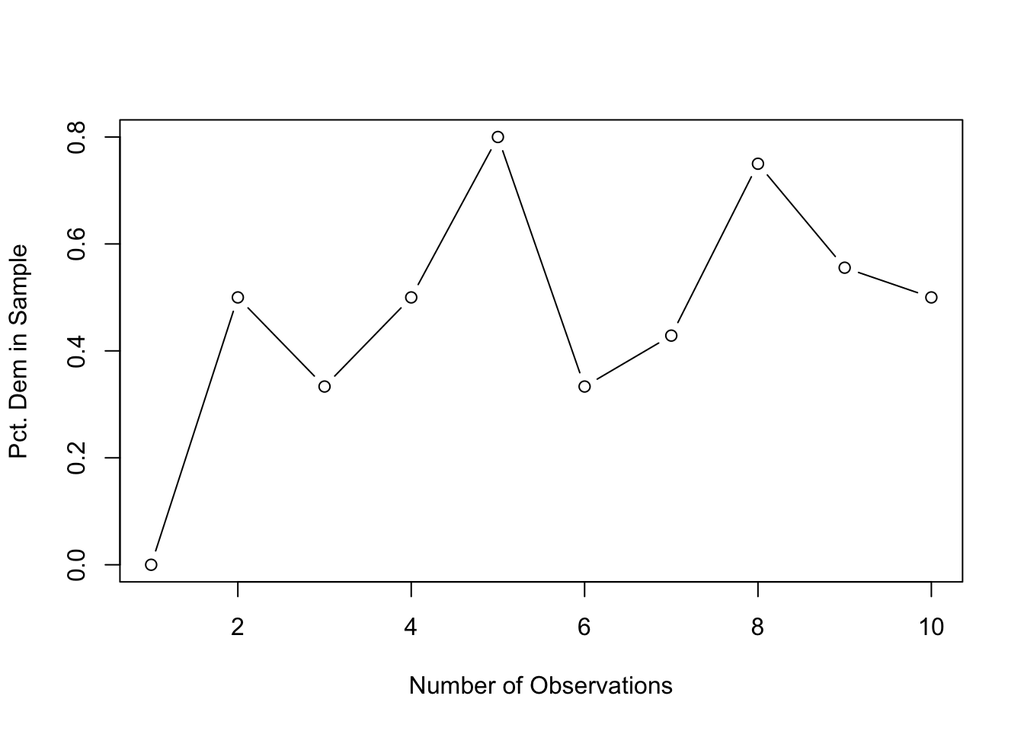

```r
plot(samplesize,dem.pty.est,
     type = "b",
     xlab = "Number of Observations",
     ylab = "Pct. Dem in Sample")
```

But remember that a graph is always to be interpreted in relation to something. What is the point we want to use the graph to make? Here, our question is how the means calculated using samples of various sizes compare to the true value and, in particular,whether larger samples are closer to the true value. If this is the goal, it is good practice to make this comparison explicit. We can do that by adding a horizontal line to the graph at the value of the true value. One way to do is to use `abline` (which is a line with an intercept of a and a slope of b) and tell it that we want a horizonal line (using `v=` would specify a vertical line) of width size 2 to highlight the truth relative to the line being plotted using the samples (i.e., `lwd=2`).

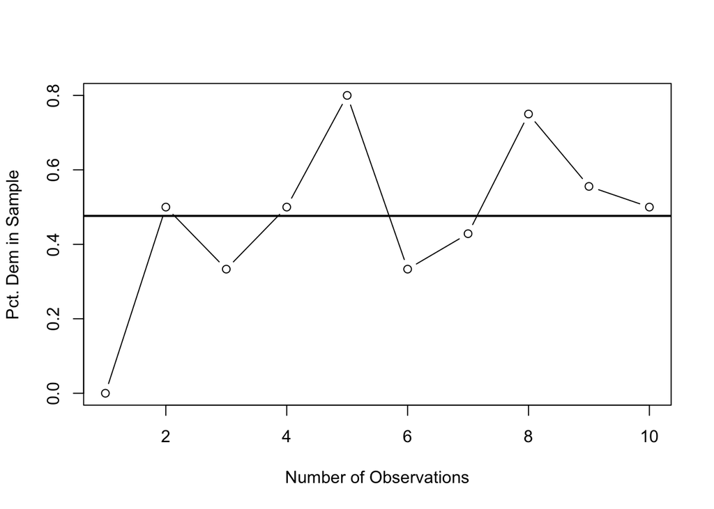

```r
plot(samplesize,dem.pty.est,
     type = "b",
     xlab = "Number of Observations",
     ylab = "Pct. Dem in Sample")
abline(h=PA.pty.breakdown[1],lwd=2)
```

```r
samplesize <- seq(1,1000)
for(i in seq_along(samplesize)){
  rand.dat <- sample_n(pa.sample,i,replace= TRUE)
  dem.pty.est[i] <- mean(rand.dat$likely.dem)
}
```

WHen we plot this now we find the following.

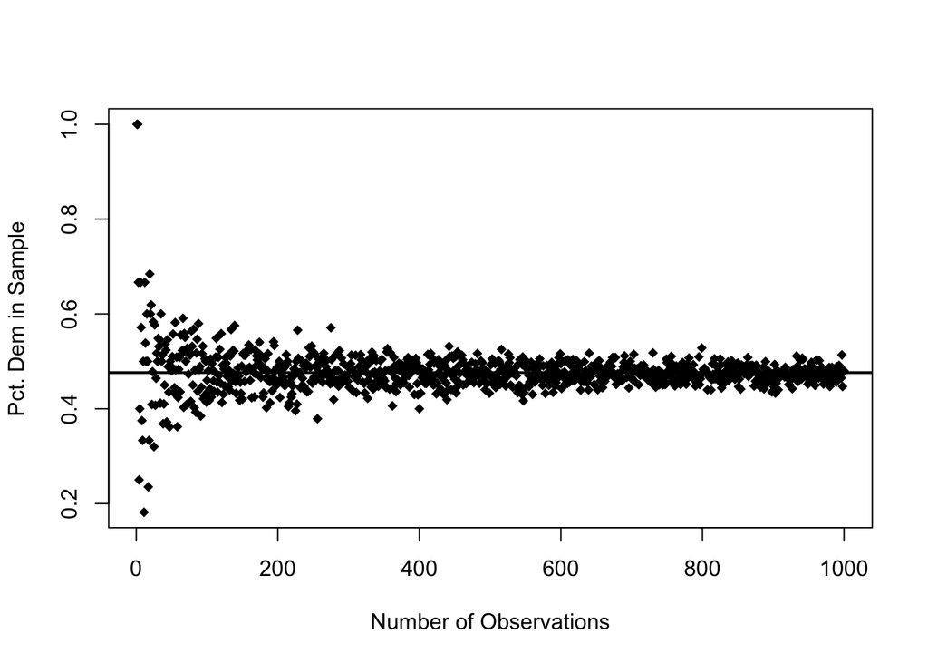

```r
plot(samplesize,dem.pty.est,
     type = "p",
     pch = 18,
     xlab = "Number of Observations",
     ylab = "Pct. Dem in Sample")
abline(h=PA.pty.breakdown[1],lwd=2)
```

So the mean of a sample from the same population can fluctuate a bit when the sample size is small, but once the sample gets to be around 30 or so the difference been the sample means varies much less. While the sample mean is rarely precisely the same as the population mean, the difference is not very large as the sample size increases.

So how much do things get better if we draw even larger samples? Instead of a sample size of 1000, what if we had 2000 data points, 5000 data points, or even 10,000 data points? Let’s find out. All we need to do to investigate this is to redefine the `samplesize` variable and plot the resulting means!

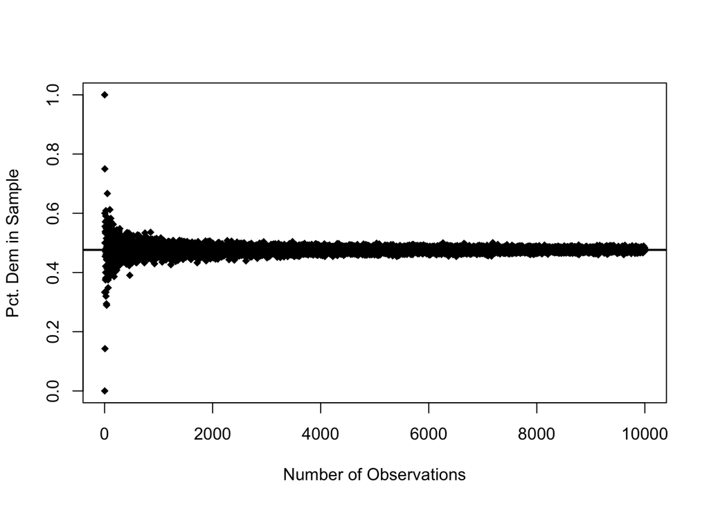

```r
samplesize2 <- seq(1,10000)
dem.pty.est2 <- NULL

for(i in seq_along(samplesize2)){
  rand.dat <- sample_n(pa.sample,i,replace= TRUE)
  dem.pty.est2[i] <- mean(rand.dat$likely.dem)
}
plot(samplesize2,dem.pty.est2,
     type = "p",
     pch = 18,
     xlab = "Number of Observations",
     ylab = "Pct. Dem in Sample")
abline(h=PA.pty.breakdown[1],lwd=2)
```

What you can see is that the sample mean continues to get a bit closer to the truth, but only slightly so. Going from a sample size of 1 to 1000 has a much bigger impact that going from a sample of 1000 to 10,000. This is why you see samples of 1000, but not 10,000. Once you get 1000 respondents there is very little gain – but perhaps a lot of cost for larger samples.

This fact – the fact that the mean of a random sample will converge to the true mean of the population – is what is called *The Law of Large Numbers*. It not only highlights the importance of random sampling – as the fact that each sample is a random sample of the larger population is critical to the result – but it is also useful for saying how many observations we ``need" to feel good about the resulting sample mean as an estimate of the true population average. In fact, we can use what we just did to directly calculate how much the sample mean varies from the truth, on average, for various sized samples!

Now create data set of samples and see how far the mean of each sample is from the true value. To do so we need to define what we mean by “far.” This is the same as defining what it means to make an error. We focus on two measures of error: the absolute error – which is the absolute value of the difference between the sample mean and the true value – and the squared error – the difference between the sample mean and the true value squared. Why can’t we just use the difference between the sample mean and the true error? WHy do we need to take the absolute value or the square of the error? The reason is that if we just use the difference than positive and negative errors would cancel and we would underestimate the true error – if the error from 2 samples was +5 and -5, for example, the average error is 0, the average absolute error is 5, and the average squared error is 25. But 0 is clearly misleading as errors were made in each.

So let’s see exactly what happens as we increase the sample size in terms of the sample mean as well as how much the sample mean varies from the true value. To do so we are going to look at the 10,000 samples ranging from 1 observation to 10,000 observations and how the average mean and average standard deviation compares as the sample size increases.

There are lots of ways to do this, but we are going to use the `cut()` function that breaks a variable into the number of equally sized groups defined by the `break` parameter. Thus, `cut(dat$samplesize2,breaks = 10)` will divide the variable `samplesize2` into 10 equally sized groups. We can then look at the mean and standard deviation of each group.

First we create a dataframe that column-binds (`cbind`) the number of data points (`samplesize2`) and the mean associated with each sample (`dem.pty.est2`) and we use the `colnames` function to label each column. We then create new variables associated with the absolute error and equared error as part of the newly created data frame (hence the assignment to `dat$Absolute.Error` instead of just `Absolute.Error`).

```r
dat <- as.data.frame(cbind(samplesize2,dem.pty.est2))
colnames(dat) <- c("samplesize2","dem.pty.est2")
dat$Absolute.Error <- dat$dem.pty.est2 - as.numeric(PA.pty.breakdown[1])
dat$Squared.Error <- (dat$dem.pty.est2 - as.numeric(PA.pty.breakdown[1]))^2
dat$cut <- cut(dat$samplesize2,breaks = 10)
table(dat$cut)
```

```
##
##    (-9,1e+03] (1e+03,2e+03] (2e+03,3e+03] (3e+03,4e+03] (4e+03,5e+03]
##          1000          1000          1000          1000          1000
## (5e+03,6e+03] (6e+03,7e+03] (7e+03,8e+03] (8e+03,9e+03] (9e+03,1e+04]
##          1000          1000          1000          1000          1000
```

```r
round(tapply(dat$Absolute.Error,dat$cut,mean), digits = 3)  # Similar error
```

```
##    (-9,1e+03] (1e+03,2e+03] (2e+03,3e+03] (3e+03,4e+03] (4e+03,5e+03]
##         0.001         0.000        -0.001        -0.001         0.000
## (5e+03,6e+03] (6e+03,7e+03] (7e+03,8e+03] (8e+03,9e+03] (9e+03,1e+04]
##         0.000         0.000         0.000         0.000         0.000
```

```r
round(tapply(dat$Absolute.Error,dat$cut,sd), digits = 3) # but less of it
```

```
##    (-9,1e+03] (1e+03,2e+03] (2e+03,3e+03] (3e+03,4e+03] (4e+03,5e+03]
##         0.043         0.013         0.010         0.008         0.007
## (5e+03,6e+03] (6e+03,7e+03] (7e+03,8e+03] (8e+03,9e+03] (9e+03,1e+04]
##         0.007         0.006         0.006         0.005         0.005
```

```r
round(tapply(dat$Squared.Error,dat$cut,mean), digits = 3) # Similar error
```

```
##    (-9,1e+03] (1e+03,2e+03] (2e+03,3e+03] (3e+03,4e+03] (4e+03,5e+03]
##         0.002         0.000         0.000         0.000         0.000
## (5e+03,6e+03] (6e+03,7e+03] (7e+03,8e+03] (8e+03,9e+03] (9e+03,1e+04]
##         0.000         0.000         0.000         0.000         0.000
```

```r
round(tapply(dat$Squared.Error,dat$cut,sd), digits = 3)  # but less of it
```

```
##    (-9,1e+03] (1e+03,2e+03] (2e+03,3e+03] (3e+03,4e+03] (4e+03,5e+03]
##         0.012         0.000         0.000         0.000         0.000
## (5e+03,6e+03] (6e+03,7e+03] (7e+03,8e+03] (8e+03,9e+03] (9e+03,1e+04]
##         0.000         0.000         0.000         0.000         0.000
```

Two findings are of importance. First, the average sample mean is always the same as the true value regardless of the sample size. The average sample mean for samples of sizes 1-1000 is as close to the true populaiton average as the average sample means for samples of size 9000-10,000. This is because we have a random sample. A random sample ensures that the sample mean can be epxected to have the same value as the population average. While any given sample may have a mean that is different – i.e., not every sample has a mean of .47 – the average of several samples is nearly indistinguishable from .47. This is due to random sampling and highlights the importance of thinking about where our data comes from and whether it is a random sample or not. If it is, we are in a very happy place.

So what is the point of this? *If our data is a random sample of the population, then the mean of the sample will be close to the mean of the population AND more observations will produce an estimate that is likely to be closer, on average. Moreover, we get really good estimates very quickly – “big” data is not needed to ensure that the mean of our same is the same as the population average, but it does ensure that the particular sample we draw is likely to be closer to the truth.*

This is why public opinion surveys of 350 million people are done with 1000 respondents!

Note that this applies to the mean of whatever quantity that you want to calculate, so this can matter. For example, we focused on calculating the percentage of likely Democrats overall – regardless of age, gender, which zip code they lived and so on. But if we wanted to calculate the percentage of Democrats who are 19 years old, female, and live in Philadelphia, then what we just did would suggest that we need a random sample of 1000 19 year-old female voters living in Philadelphia. So if we are interested in particular subgroups in the population – especially if we are interested in the opinions of those with intersectional identities for example – then the number of observations we need to be able to precisely estimate the average opinion may be much higher. Even then, we can use this information to help quantify how much our estimates might change if we were able to take another random sample.

# Second Cool Result: Central Limit Theorem

Ok, so what we have just shown is that *if we have a random sample* then as the number of observations increases the mean of the sample will get closer and closer to the true average in the population being sampled from. To be clear, the mean of a random sample is always expected to be have an expected value that is the population mean. This is why the average sample mean in the prior section was always the same as the true value.

We also found that as the sample size increases the sample mean of a particular size sample is more likely to be closer to the truth.

But can we say something more? Can we say anything about how a sample mean might vary from the true value? Put differently, if we were to draw 1000 samples of 10 observations and do a histogram of the resulting 1000 sample means, what would it look like? In particular, does the distribution of the sample mean for random samples follow a particular known and knowable distribution?

Why do we care? Because if it does, then this means that we can use math to make statements about how likely a sample mean of a random sample is to vary from the true population value. Put differently, we could evaluate the uncertainty of an estimate analytically rather than computationally – something that can be very, very useful if we have a lot of data!

The second cool result we are going to talk about is the Central Limit Theorem and it answers this question in the affirmative. The CLT says that if we were to take repeated random samples of the same size from a common population than the distribution of those sample means would be normally distributed around the true population value.

While you can prove this analytically using math, lets illustrate this using the resampling skills we are working on. The basic task is to create multiple samples from the same population, compute the mean for each of those samples, and then plot the resulting distribution of sample means. So let’s dive in.

Let’s start by choosing our sample size – say 1000 – and the number of samples that we want to do – say 5. Now use a loop to draw 5 samples and calculate the mean associated with each one. Note how the loop here differs from earlier. In earlier loops we had a sequence and we used `seq_along` to loop through the variable containing the sequence. We could do the same here by creating a sequence from 1 to 5 and then using that to define the loop or else we can use the syntax used below that tells the loop to start with 1=1 and proceed to i=5 by iterating by 1 each time – this is the interpretation of `i in 1:5` snippet.

```r
# Fix Sample Size, Vary number of Samples
n.samplesize <- 1000
n.samples <- 5

est.sample5 <- NULL
for(i in 1:5){
    rand.dat <- sample_n(pa.sample,n.samplesize,replace= TRUE)
    est.sample5[i] <- mean(rand.dat$likely.dem)
  }
```

Now let’s see what the distribution of those 5 samples looks like using a histogram. Ugly. Doesn’t really look like anything.

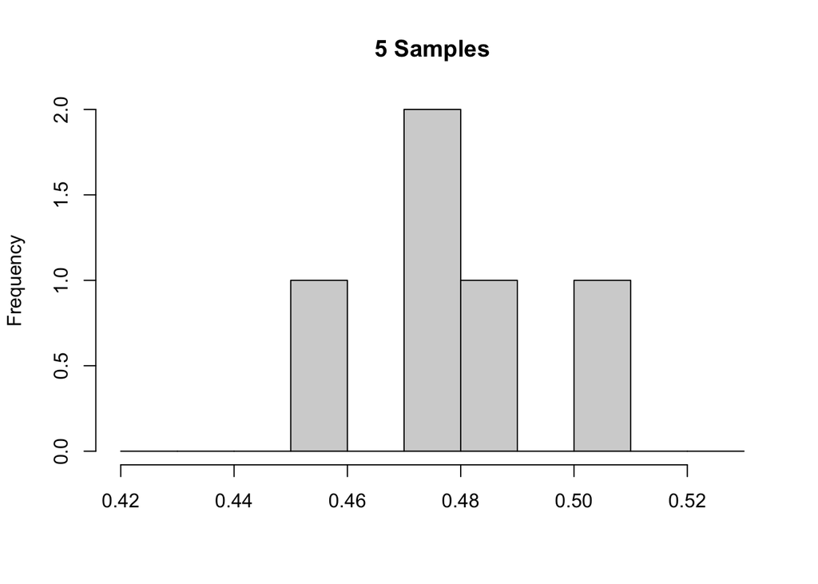

```r
hist(est.sample5, main = "5 Samples", breaks=seq(.42,.53,by=.01),xlim=c(.42,.53),xlab="")
```

So let’s ramp things up and see what happens if we take 10 samples of size 1000, and 20 samples of size 1000, and then 40, 80, and 160 samples of 1000 observations each. This code is clunky and not as clean as it could be, but let’s keep it so to give you practice in reading and writing loops.

```r
est.sample10 <- NULL
for(i in 1:10){
  rand.dat <- sample_n(pa.sample,n.samplesize,replace= TRUE)
  est.sample10[i] <- mean(rand.dat$likely.dem)
}

est.sample20 <- NULL
for(i in 1:20){
  rand.dat <- sample_n(pa.sample,n.samplesize,replace= TRUE)
  est.sample20[i] <- mean(rand.dat$likely.dem)
}

est.sample40 <- NULL
for(i in 1:40){
  rand.dat <- sample_n(pa.sample,n.samplesize,replace= TRUE)
  est.sample40[i] <- mean(rand.dat$likely.dem)
}

est.sample80 <- NULL
for(i in 1:80){
  rand.dat <- sample_n(pa.sample,n.samplesize,replace= TRUE)
  est.sample80[i] <- mean(rand.dat$likely.dem)
}

est.sample160 <- NULL
for(i in 1:160){
  rand.dat <- sample_n(pa.sample,n.samplesize,replace= TRUE)
  est.sample160[i] <- mean(rand.dat$likely.dem)
}
```

Now that we have created all of these variables consisting of sample means based on 1000 random samples let’s plot the histograms associated with each. Note that we are using `par()` command to define the graphical parameters. In particular, the `mfrow=c(2,3)` tells R to arrange the plots that follow into 2 rows and 3 columns and to fill in the plots by row. Thus, the first plot that follows will go in the upper left, the second will go in the upper middle, the third will go in the upper right, the fourth will go in the lower left, the fifth will go in the middle lower, and the sixth will go in the lower right.

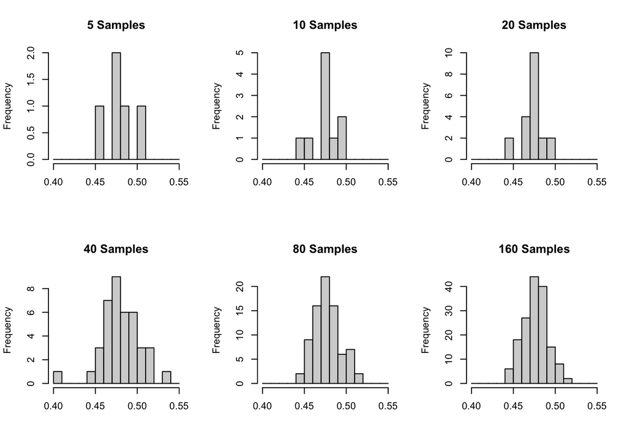

```r
par(mfrow=c(2,3))
hist(est.sample5, main = "5 Samples", breaks=seq(.40,.55,by=.01),xlim=c(.40,.55),xlab="")
hist(est.sample10, main = "10 Samples", breaks=seq(.40,.55,by=.01),xlim=c(.40,.55),xlab="")
hist(est.sample20, main = "20 Samples", breaks=seq(.40,.55,by=.01),xlim=c(.40,.55),xlab="")
hist(est.sample40, main = "40 Samples", breaks=seq(.40,.55,by=.01),xlim=c(.40,.55),xlab="")
hist(est.sample80, main = "80 Samples", breaks=seq(.40,.55,by=.01),xlim=c(.40,.55),xlab="")
hist(est.sample160, main = "160 Samples", breaks=seq(.40,.55,by=.01),xlim=c(.40,.55),xlab="")
```

This clear shows that as the number of samples we draw gets larger the distribution of the sample means seems more and more similar to a normal distribution. Let’s take it up a notch and see what happens if we take 5000 samples of size 1000 and plot the distribution of the 5000 sample means.

```r
par(mfrow=c(1,1))

est.sample5000 <- NULL
for(i in 1:5000){
  rand.dat <- sample_n(pa.sample,n.samplesize,replace= TRUE)
  est.sample5000[i] <- mean(rand.dat$likely.dem)
}
```

Well that looks pretty darn normal. But can we check? Let’s use the fact that R can use the distribution of the normal distribution `dnorm` (as well as many other common distributions) to compare the histogram of the sample means to a normal distribution with mean 0 and variance 1 (i.e., what is called a “standard normal” distribution). To make this comparison we are first going to “standardize” our variable of sample means by subtracting off the mean of the 5000 sample means and dividing by the standard deviation of the sample means. This will transform the variable of sample means to a variable with a mean of zero and a standard deviation of 1 and allow us to directly compare the histogram of standardized sample means against a standard normal distribution.

Let’s do this!

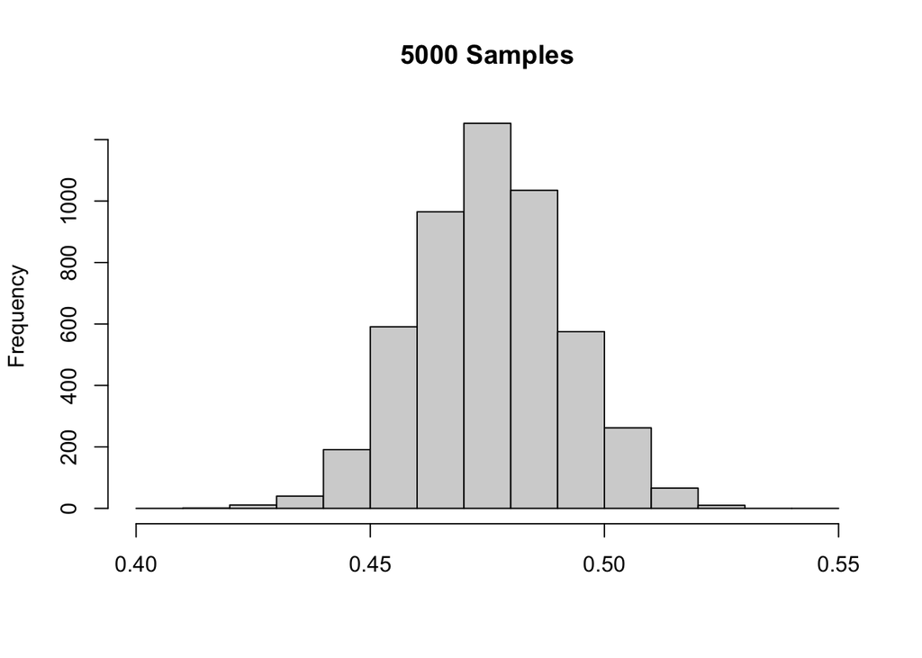

```r
# Looks really normal, but can we be more specific?
hist(est.sample5000, main = "5000 Samples", breaks=seq(.40,.55,by=.01),xlim=c(.40,.55),xlab="")
```

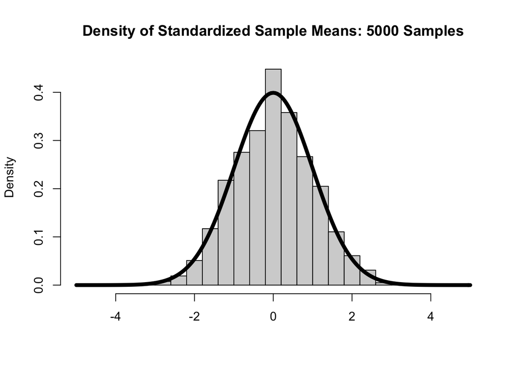

```r
# Let's standardize:
# subtract off the mean of the sample (so that the mean of the 5000 is now 0)
# divide by the standard deviation of the sample (so that the sd of the 5000 means is now 1)

stand.est.sample5000 <- (est.sample5000 - mean(est.sample5000))/sd(est.sample5000)

hist(stand.est.sample5000,
     main="Density of Standardized Sample Means: 5000 Samples",
     xlab="",
     breaks=seq(-5,5,by=.4),
     freq = FALSE,
     xlim=c(-5,5))

x <- seq(-5,5,by=.05)
y <- dnorm(x)
points(x,y,type="l",lwd=5)
```

What you see is that the histogram of sample means tracks the standard normal distribution nearly identically!

This is amazing. Despite the fact that we have no idea what the distribution of partisanship is in the state of PA, it turns out that the distribution of the sample mean is normally distributed around the truth population average. This is the basis for so much of the statistical analysis that you will see being done – the fact that the sample mean is distributed normally means that we can then use the properties of the normal distribution to make statements about the probability that an estimate will contain a particular value. Or how likely it is that the true population average may be X away from the sample mean being calculated. This result is absolutely fundamental to statistics because it provides the ability to analytically determine the precision of a sample mean of a random sample.

Now, to be fair, it is also a bit weird in terms of what it is saying. Recall that what we are doing is taking repeated samples of the same size from the population and then computing the distribution of those sample means. But in reality we are only doing a single study or a single data collection. No one does 10 simultaneous public opinion polls of a 1000 respondents each (as that would be the same as a single poll of 10,000!). Instead, you should think about this result – and also the LLN – as results that are based on hypothetical conditions. Even though we only ever do a single sample from the population, we can use what we know about how much the sample mean might vary if we were to do the same study over and over again to quantify our uncertainty about the one study we did.

# Application: Margin of Error

So let’s make bring this back to reality. We can use these results and the resampling tools we have learned along the way to quantify how much a poll results may differ *because of the random sampling being done.* That is, if we were do the study again by drawing a new random sample, how much might the results change? In survey research and public opinion polling this is what is called the ``margin of error." Note that this is not the same as the amount of polling error for reasons that we will explore it exquisite and excruciating detail!

Let’s return to the task of estimating the percentage of likely Democrats in teh state of PA based on the voter file. Let’s take a sample of 1000 – a sample size that is fairly typical in political polling – and draw a random sample from the voter file that we will call `my.sample`. Then compute the percentage of likely Democrats in `my.sample` and also the voter file overall (`pa.sample`).

# How do we use this?

```r
# Do the study
n.samplesize <- 1000
my.sample <- sample_n(pa.sample,n.samplesize,replace= TRUE)

mean(my.sample$likely.dem)
```

```
## [1] 0.465
```

```r
mean(pa.sample$likely.dem) # Truth
```

```
## [1] 0.4762857
```

```r
mean(my.sample$likely.dem) - mean(pa.sample$likely.dem) # Truth
```

```
## [1] -0.01128567
```

The difference is small – -0.0112857 – a result we would expect given the Law of Large Numbers discussed previously. But we care more about a point estimate. Good science requires quantifying how certain we are of that estimate. How much might the results change if we were to take another random sample. Random sampling ensures that the sample mean will be the same as the population average on average, but how far away might our particular sample be? How wrong might our sample be because of the particular random sample we took? (Note that this quantification of error is very precise in that it refers to the error due to random sampling. Whether the measure of likely partisanship is accurate – which is seems likely not to be given the lopsided distribution – is another source of error entirely. The effect of measurement error is distinct from the effect of sampling error that we are focusing on!)

So how can we quantify our uncertainty? We know that there is some error due to sampling variability by the fact that the two means are not identical. But how much might the sample mean differ from the true population average? We are going to use the tools of resampling and the fact that we can use the resulting samples to make inferences about any statistic of the resulting samples. This is a remarkable result due to two brilliant Stanford statisticians (Go Cardinal!) Efron and Tibsurani called the “Bootstrap” (ANd the closely related “jacknife”). We are not going to go through the math as to why it works, but the basic idea is that we can take an arbitrarily large number of samples from the sample we collected and use those samples to see how much our estimates may change. The thing that makes this all work is the power of random sampling. Because our sample is a random sample of the population of interest, any sample from our sample is also a random sample from the population. Thus, we can simply sample from our sample to learn about the uncertainty in our estimates.

If that seems abstract, let’s walk thru the code to make it real. We begin by choosing a large number to define how many samples we are going to draw. Let’s choose 5000. Now what we are going to do is to draw 5000 samples *from our sample* and compute the mean for each of the 5000 samples. This will produce a variable of 5000 sample means called `resample5000`.

Why are we drawing from our sample (`my.sample`) rather than the voter file (`pa.sample`? Because we are trying to simulate what we would have to do if we did not know the true population and we were forced to use our random sample to approximate the population.

```r
# Now use that study to approximate the truth (random sampling, iid) via resampling
# Pick some large number of hypothetical samples
B <- 5000
resample5000 <- NULL
for(i in 1:B){
  rand.dat <- sample_n(my.sample,n.samplesize,replace= TRUE)
  resample5000[i] <- mean(rand.dat$likely.dem)
}
```

```r
quantile(resample5000,c(.05,.95)) # Contains 90% of the means
```

```
##    5%   95%
## 0.439 0.490
```

We can do the same to define the range containing 95% of the sample means. Note that it is slight larger, as expected because we want the interval containing 95% of the sample means.

```r
quantile(resample5000,c(.025,.975)) # Contains 95% of the means
```

```
##  2.5% 97.5%
## 0.435 0.495
```

```r
# Notice True value is solidly within!
```

Note that this is the same as the 95% confidence intervals that you may have seen in other statistics classes. Interpreted correctly, the 95% confidence interval is the interval that contains 95% of the sample means if you were to take multiple random samples from the population and compute the mean. You sometimes hear people talk about the 95% confidence interval as a statement about being 95% confident that the true value is between the recovered values, but that is not strictly correct. Despite the somewhat misleading name, confidence intervals are not a statement about our confidence in the estimate – for that see the field of Bayesian statistics. Instead, “confidence” refers to how much we would expect the statistic we calculate to vary if we took repeated random samples from the population of interest and we computed the statistic of interest each time. It is a statement about the distribution of estimates that would happen in the hypothetical world in which we were able to take infinitely many samples. If that seems bizarre, you are not alone in your initial confusion. It often takes awhile for the reality of a confidence interval to sink in, but hopefully the process of using resampling to compute the 95% confidence interval illustrates exactly what it means because how we computed it is precisely what it means!

So how does this relate to the margin of error? When we see that a poll of 1000 people has a margin of error of +/- 3 where does that come from? It comes from the calculation we just did! In particular, if we subtract off the sample mean we get a statement of how much the sample mean varies between the 2.5 percentile and the 97.5 percentile of the 5000 sample means that we resampled. In terms of the code we get:

```r
quantile(resample5000,c(.025,.975)) - mean(my.sample$likely.dem)
```

```
##  2.5% 97.5%
## -0.03  0.03
```

And what if we only have a sample of 100 respondents? Now we redo all of the code we just did except we define our original sample – `my.sample` – as containing only 100 observations.

```r
my.sample <- sample_n(pa.sample,100,replace= TRUE)
resample5000 <- NULL
for(i in 1:5000){
  rand.dat <- sample_n(my.sample,100,replace= TRUE)
  resample5000[i] <- mean(rand.dat$likely.dem)
}

# "Margin of Error?"
quantile(resample5000,c(.025,.975)) - mean(my.sample$likely.dem)
```

```
##  2.5% 97.5%
## -0.10  0.09
```

And you can see that with only 100 respondents the margin of error is now +/- 10 percentage points. So if you are trying to learn about a population and you only have 100 observations from that population then your certainty in what you can say is considerably less than if you had 1000 observations.

And if we were able to collect data on 10,000 observations? What then? Let’s see!

```r
my.sample <- sample_n(pa.sample,10000,replace= TRUE)
resample1000 <- rep(NA,times=1000)
for(j in 1:1000){
  rand.dat <- sample_n(my.sample,10000,replace= TRUE)
  resample1000[j] <- mean(rand.dat$likely.dem, na.rm=TRUE)
}
quantile(resample1000,c(.975)) - mean(my.sample$likely.dem)
```

```
## 97.5%
##  0.01
```

Note that this time that instead of calculate both the 2.5 percentile and the 97.5 percentile we just calculated the 97.5 percentile given the symmetry of the normal distribution and used the result to characterize the margin of error as being +/- 0.01.

So how quickly does the margin of error decrease for various sample sizes? Well we can use the tools we have developed to explore this relationship. What we are going to do is to define a sequence of increasing sample sizes – the variable `samplesizes` – and a placeholder variable `moe` to capture the margin of error associated with each sized sample. Then for each sample size in `samplesize` we are going to draw a random sample from the voter file called `my.sample` and, using this sample, create 1000 samples from that sample. (Note that we are drawing a different `my.sample` for each sample size in `samplesize`, but we are using the same `my.sample` to generate the 1000 samples for each sample size in `samplesize`.) For each of the 1000 samples we calculate the mean and then we compute the differences between the sample mean of `my.sample` and the sample mean of the 97.5 percentile of the 1000 samples to calculate the margin of error (again relying on the symmetry).

Note how we are using two loops to do this – an outer loop that allows the sample size to vary depending on the sequence defined in `samplesizes` and an inner loop that selects a single sample from the voter file where the number of observations is given by the ith value of `samplesize` and then genrates 1000 samples from the sample from which to calculate the margin of error associated with the sample size given by the ith value of `samplesize`.

```r
samplesizes <- c(10,100,200,300,400,500,600,700,800,900,1000,5000,10000)

moe <- rep(NA,length(samplesizes))

for(i in seq_along(samplesizes)){
  my.sample <- sample_n(pa.sample,samplesizes[i],replace= TRUE)

  resample1000 <- rep(NA,times=1000)
  for(j in 1:1000){
    rand.dat <- sample_n(my.sample,samplesizes[i],replace= TRUE)
    resample1000[j] <- mean(rand.dat$likely.dem)
  }
  moe[i] <- quantile(resample1000,c(.975)) - mean(my.sample$likely.dem)
}
```

With this, we can now plot how the margin of error (based on our 1000 bootstrap samples computed in the inner loop) varies according to the sample size being analyzed (based on the outerloop defined by the sequence of sample sizes in `samplesize`).

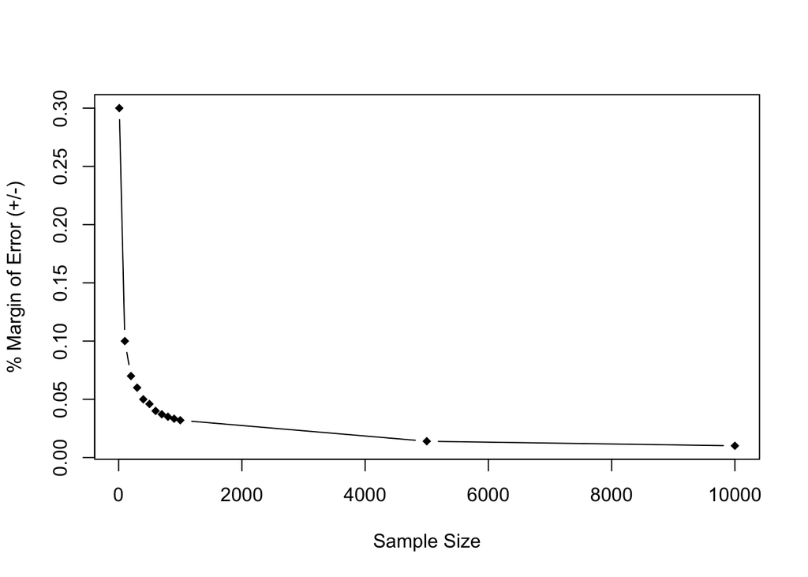

```r
plot(samplesizes,moe,
     type="b",
     pch=18,
     xlab="Sample Size",
     ylab="% Margin of Error (+/-)")
```

# Questions for Review:

1. Why is random sampling important?
2. What does the Law of Large Numbers say?
3. Why is the Central Limit Theorem important?
4. The interquartile range is the interval containing the 25th and 75th percentiles of the data. Can you adapt the code to show how width of the interquartile range varies as the sample size increases?
5. Can you replicate the margin of error calculations for the percentage of independents? Compared to the size of the margin of error for Likely Democrats, how does the size of the margin of error for the percentage of independents compare?
[^1]: iid